# **Bootcamp Ciencia de Datos e Inteligencia Artificial**

# **Proyecto Módulo 1. Python para Ciencia de Datos**

### Imporación de dataframes

```
   ID Marca                           Modelo  RAM_GB  ROM_GB  Calificaciones  \
0        10      Redmi 8 (Onyx Black, 64 GB)       4      64          674638
1         9  Realme 5i (Forest Green, 64 GB)       4      64          243106
2         9     Realme 5i (Aqua Blue, 64 GB)       4      64          243106
3        10   Redmi 8 (Sapphire Blue, 64 GB)       4      32          674638
4         8  POCO X2 (Matrix Purple, 128 GB)       6      64          133486

   Rese–as  Estrellas  Precio de lista  Precio de venta
0    50064        4.4            10999             9999
1    16497        4.5            10999            10999
2    16497        4.5            10999            10999
3    50064        4.4            10999             9999
4    14732        4.5            19999            18499


   ID Marca Nombre Marca
0         1        Apple
1         2       I Kall
2         3      Infinix
3         4         Lava
4         5     Motorola
```

```
El número de filas que tiene df_modelos es: 120
El número de filas que tiene df_marcas es: 12
```

### Combinación de dataframes

|  | ID Marca | Modelo | RAM_GB | ROM_GB | Calificaciones | Rese–as | Estrellas | Precio de lista | Precio de venta | Nombre Marca |
| --- | --- | --- | --- | --- | --- | --- | --- | --- | --- | --- |
| 0 | 10 | Redmi 8 (Onyx Black, 64 GB) | 4 | 64 | 674638 | 50064 | 4.4 | 10999 | 9999 | Redmi |
| 1 | 10 | Redmi 8 (Sapphire Blue, 64 GB) | 4 | 32 | 674638 | 50064 | 4.4 | 10999 | 9999 | Redmi |
| 2 | 10 | Redmi Note 8 Pro (Electric Blue, 128 GB) | 6 | 64 | 55815 | 4614 | 4.4 | 17999 | 16999 | Redmi |
| 3 | 10 | Redmi 8A Dual (Sea Blue, 64 GB) | 3 | 64 | 974 | 71 | 4.3 | 9750 | 9750 | Redmi |
| 4 | 10 | Redmi 8A Dual (Sea Blue, 32 GB) | 2 | 64 | 1246 | 81 | 4.2 | 8320 | 8320 | Redmi |

### Análisis del dataframe

|  | ID Marca | Modelo | RAM_GB | ROM_GB | Calificaciones | Rese–as | Estrellas | Precio de lista | Precio de venta | Nombre Marca |
| --- | --- | --- | --- | --- | --- | --- | --- | --- | --- | --- |
| 0 | 10 | Redmi 8 (Onyx Black, 64 GB) | 4 | 64 | 674638 | 50064 | 4.4 | 10999 | 9999 | Redmi |
| 2 | 10 | Redmi Note 8 Pro (Electric Blue, 128 GB) | 6 | 64 | 55815 | 4614 | 4.4 | 17999 | 16999 | Redmi |
| 3 | 10 | Redmi 8A Dual (Sea Blue, 64 GB) | 3 | 64 | 974 | 71 | 4.3 | 9750 | 9750 | Redmi |
| 4 | 10 | Redmi 8A Dual (Sea Blue, 32 GB) | 2 | 64 | 1246 | 81 | 4.2 | 8320 | 8320 | Redmi |
| 5 | 10 | Redmi 8A Dual (Sky White, 32 GB) | 2 | 64 | 1246 | 81 | 4.2 | 8499 | 8249 | Redmi |
| ... | ... | ... | ... | ... | ... | ... | ... | ... | ... | ... |
| 109 | 2 | I Kall K400 (Blue, 64 GB) | 4 | 64 | 512 | 47 | 2.8 | 7299 | 7299 | I Kall |
| 111 | 2 | I Kall K1000 (Blue, 64 GB) | 4 | 64 | 840 | 111 | 2.9 | 7699 | 7699 | I Kall |
| 113 | 2 | I Kall K400 (Blue, 64 GB) | 4 | 64 | 512 | 47 | 2.8 | 7299 | 7299 | I Kall |
| 114 | 2 | I Kall K14 New | 32 | 64 | 7229 | 822 | 3.4 | 609 | 609 | I Kall |
| 115 | 6 | Nokia 105 SS | 4 | 64 | 75730 | 7229 | 4.3 | 1299 | 1299 | Nokia |

62 rows × 10 columns

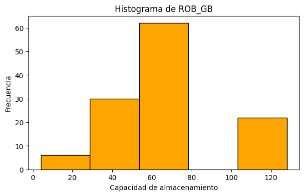

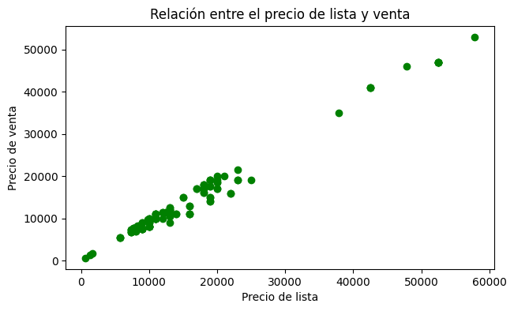

##### **Análisis de la gráfica**

De la inspección de la gráfica se puede llegar a la conclusión de que el precio de venta está relacionado positivamente con el precio de lista, es decir, el aumento en una se relaciona con el aumento de la otra. Además, en la mayoría de observaciones los precios de ambos difieren por muy poco, distribuyéndose la mayoría alrededor de 0 y menos de 30.000.

### Información del dataframe

```
El promedio de los precios de venta de los modelos marca Realme es 12423.24
El máximo de estrellas de los modelos marca Redmi es 4.4
El mínimo de estrellas de los modelos marca Redmi es 4.2
```

```
Nombre Marca
Apple       4.554545
I Kall      2.984615
Infinix     4.387500
Lava        4.100000
Motorola    4.400000
Nokia       4.300000
Oppo        4.325000
Poco        4.500000
Realme      4.475758
Redmi       4.340000
Tecno       4.266667
Vivo        4.375000
Name: Estrellas, dtype: float64
```

| Nombre Marca | Calificaciones | Rese–as | Estrellas | Precio de venta |
| --- | --- | --- | --- | --- |
| Apple | 13517.272727 | 1263.181818 | 4.554545 | 44726.272727 |
| I Kall | 1023.384615 | 113.538462 | 2.984615 | 6322.846154 |
| Infinix | 9066.375000 | 740.750000 | 4.387500 | 9936.500000 |
| Lava | 361.000000 | 34.000000 | 4.100000 | 1699.000000 |
| Motorola | 27992.000000 | 2199.000000 | 4.400000 | 9499.000000 |
| Nokia | 75730.000000 | 7229.000000 | 4.300000 | 1299.000000 |
| Oppo | 10612.625000 | 891.125000 | 4.325000 | 12990.000000 |
| Poco | 115201.200000 | 12750.400000 | 4.500000 | 18699.000000 |
| Realme | 111534.454545 | 8935.212121 | 4.475758 | 12423.242424 |
| Redmi | 152829.800000 | 11489.500000 | 4.340000 | 12410.300000 |
| Tecno | 4680.333333 | 544.333333 | 4.266667 | 10999.000000 |
| Vivo | 32154.687500 | 2969.562500 | 4.375000 | 13052.500000 |

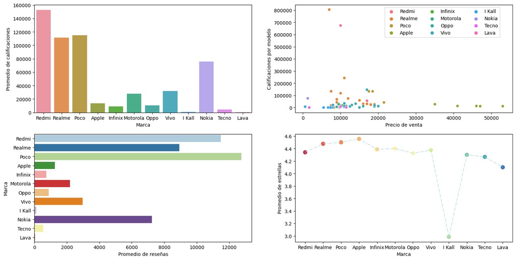

#### Análisis Final

De los datos analizados se puede inferir que un mayor promedio de reseñas o de calificaciones en línea puede influir en una mayor puntuación o estrellas según la marca del teléfono, ya que Redmi, Realme y Poco son las 3 marcas que más reseñas y calificaciones tienen y, asimismo, Realme y Poco tienen 2 de los puntajes promedio de estrellas más altos, siendo solo superados por Apple.

Por otro lado, la mayoría de las calificaciones corresponden a teléfonos con precios menores a 25.000. Solo unas pocas calificaciones se realizan a teléfonos de mayor precio que son de marca Apple. A pesar de que esta marca no tiene un gran número de calificaciones ni de reseñas, es la que mayor puntaje promedio de estrellas tiene.

Esto lleva a concluir que hay variables no consideradas que influyen en gran medida el puntaje de los teléfonos independientemente del número de calificaciones y reseñas que tengan.

```
[NbConvertApp] Converting notebook analisis_marcas_celulares.ipynb to html
[NbConvertApp] Writing 822922 bytes to analisis_marcas_celulares.html
```